# STA510 Final Project

```r
library(tidyverse)
library(tidyr)
library(ggplot2)
library(glmnet)
library(dplyr)
library(car)
```

```r
df <- read.csv('M1_final.csv')
head(df)
```

|  | MONTH | DAY_OF_MONTH | DAY_OF_WEEK | OP_UNIQUE_CARRIER | TAIL_NUM | DEST | DEP_DELAY | CRS_ELAPSED_TIME | DISTANCE | CRS_DEP_M | DEP_TIME_M | CRS_ARR_M | Temperature | Dew.Point | Humidity | Wind | Wind.Speed | Wind.Gust | Pressure | Condition | sch_dep | sch_arr | TAXI_OUT |
| --- | --- | --- | --- | --- | --- | --- | --- | --- | --- | --- | --- | --- | --- | --- | --- | --- | --- | --- | --- | --- | --- | --- | --- |
| 1 | 11 | 1 | 5 | B6 | N828JB | CHS | -1 | 124 | 636 | 324 | 323 | 448 | 48 | 34 | 58 | W | 25 | 38 | 29.86 | Fair / Windy | 9 | 17 | 14 |
| 2 | 11 | 1 | 5 | B6 | N992JB | LAX | -7 | 371 | 2475 | 340 | 333 | 531 | 48 | 34 | 58 | W | 25 | 38 | 29.86 | Fair / Windy | 9 | 17 | 15 |
| 3 | 11 | 1 | 5 | B6 | N959JB | FLL | 40 | 181 | 1069 | 301 | 341 | 482 | 48 | 34 | 58 | W | 25 | 38 | 29.86 | Fair / Windy | 9 | 17 | 22 |
| 4 | 11 | 1 | 5 | B6 | N999JQ | MCO | -2 | 168 | 944 | 345 | 343 | 513 | 48 | 34 | 58 | W | 25 | 38 | 29.86 | Fair / Windy | 9 | 17 | 12 |
| 5 | 11 | 1 | 5 | DL | N880DN | ATL | -4 | 139 | 760 | 360 | 356 | 499 | 46 | 32 | 58 | W | 24 | 35 | 29.91 | Fair / Windy | 9 | 17 | 13 |
| 6 | 11 | 1 | 5 | AA | N983NN | ORD | -1 | 161 | 740 | 359 | 358 | 460 | 46 | 32 | 58 | W | 24 | 35 | 29.91 | Fair / Windy | 9 | 17 | 21 |

```r
summary(df)
```

```
     MONTH         DAY_OF_MONTH    DAY_OF_WEEK    OP_UNIQUE_CARRIER
 Min.   : 1.000   Min.   : 1.00   Min.   :1.000   Length:28820
 1st Qu.: 1.000   1st Qu.: 8.00   1st Qu.:2.000   Class :character
 Median :11.000   Median :16.00   Median :4.000   Mode  :character
 Mean   : 7.894   Mean   :16.02   Mean   :4.009
 3rd Qu.:12.000   3rd Qu.:24.00   3rd Qu.:6.000
 Max.   :12.000   Max.   :31.00   Max.   :7.000
   TAIL_NUM             DEST             DEP_DELAY        CRS_ELAPSED_TIME
 Length:28820       Length:28820       Min.   : -22.000   Min.   : 57.0
 Class :character   Class :character   1st Qu.:  -6.000   1st Qu.:124.0
 Mode  :character   Mode  :character   Median :  -3.000   Median :188.0
                                       Mean   :   6.375   Mean   :225.3
                                       3rd Qu.:   2.000   3rd Qu.:365.0
                                       Max.   :1276.000   Max.   :697.0
    DISTANCE      CRS_DEP_M      DEP_TIME_M       CRS_ARR_M       Temperature
 Min.   :  94   Min.   : 301   Min.   :   1.0   Min.   :   1.0   Min.   :17.00
 1st Qu.: 483   1st Qu.: 545   1st Qu.: 542.0   1st Qu.: 667.0   1st Qu.:36.00
 Median :1029   Median : 856   Median : 854.0   Median : 918.0   Median :42.00
 Mean   :1268   Mean   : 831   Mean   : 828.9   Mean   : 910.9   Mean   :41.49
 3rd Qu.:2248   3rd Qu.:1095   3rd Qu.:1097.0   3rd Qu.:1193.0   3rd Qu.:47.00
 Max.   :4983   Max.   :1439   Max.   :1440.0   Max.   :1439.0   Max.   :68.00
  Dew.Point            Humidity         Wind             Wind.Speed
 Length:28820       Min.   : 0.00   Length:28820       Min.   : 0.00
 Class :character   1st Qu.:46.00   Class :character   1st Qu.: 8.00
 Mode  :character   Median :59.00   Mode  :character   Median :12.00
                    Mean   :57.73                      Mean   :12.37
                    3rd Qu.:74.00                      3rd Qu.:16.00
                    Max.   :97.00                      Max.   :36.00
   Wind.Gust         Pressure      Condition            sch_dep         sch_arr
 Min.   : 0.000   Min.   :29.20   Length:28820       Min.   : 0.00   Min.   : 0.00
 1st Qu.: 0.000   1st Qu.:29.88   Class :character   1st Qu.:26.00   1st Qu.:21.00
 Median : 0.000   Median :30.11   Mode  :character   Median :30.00   Median :30.00
 Mean   : 5.535   Mean   :30.09                      Mean   :31.09   Mean   :28.43
 3rd Qu.: 0.000   3rd Qu.:30.32                      3rd Qu.:37.00   3rd Qu.:35.00
 Max.   :49.000   Max.   :30.75                      Max.   :55.00   Max.   :46.00
    TAXI_OUT
 Min.   : 5.00
 1st Qu.:16.00
 Median :19.00
 Mean   :20.86
 3rd Qu.:25.00
 Max.   :41.00
```

```r
df$Dew.Point <- as.numeric(iconv(df$Dew.Point, 'utf-8', 'ascii', sub=''))
summary(df$Dew.Point)
```

```
   Min. 1st Qu.  Median    Mean 3rd Qu.    Max.
  -3.00   23.00   31.00   30.42   39.00   67.00
```

```r
df[df == ''] <- NA
sum(is.na(df))
```

```
[1] 2
```

```r
df <- na.omit(df)
dim(df)
```

```
[1] 28818    23
```

```r
set.seed(1)

sample <- sample(c(TRUE, FALSE), nrow(df), replace=TRUE, prob=c(0.9,0.1))
train  <- df[sample, ]
test   <- df[!sample, ]

head(train)
```

|  | MONTH | DAY_OF_MONTH | DAY_OF_WEEK | OP_UNIQUE_CARRIER | TAIL_NUM | DEST | DEP_DELAY | CRS_ELAPSED_TIME | DISTANCE | CRS_DEP_M | DEP_TIME_M | CRS_ARR_M | Temperature | Dew.Point | Humidity | Wind | Wind.Speed | Wind.Gust | Pressure | Condition | sch_dep | sch_arr | TAXI_OUT |
| --- | --- | --- | --- | --- | --- | --- | --- | --- | --- | --- | --- | --- | --- | --- | --- | --- | --- | --- | --- | --- | --- | --- | --- |
| 1 | 11 | 1 | 5 | B6 | N828JB | CHS | -1 | 124 | 636 | 324 | 323 | 448 | 48 | 34 | 58 | W | 25 | 38 | 29.86 | Fair / Windy | 9 | 17 | 14 |
| 2 | 11 | 1 | 5 | B6 | N992JB | LAX | -7 | 371 | 2475 | 340 | 333 | 531 | 48 | 34 | 58 | W | 25 | 38 | 29.86 | Fair / Windy | 9 | 17 | 15 |
| 3 | 11 | 1 | 5 | B6 | N959JB | FLL | 40 | 181 | 1069 | 301 | 341 | 482 | 48 | 34 | 58 | W | 25 | 38 | 29.86 | Fair / Windy | 9 | 17 | 22 |
| 5 | 11 | 1 | 5 | DL | N880DN | ATL | -4 | 139 | 760 | 360 | 356 | 499 | 46 | 32 | 58 | W | 24 | 35 | 29.91 | Fair / Windy | 9 | 17 | 13 |
| 6 | 11 | 1 | 5 | AA | N983NN | ORD | -1 | 161 | 740 | 359 | 358 | 460 | 46 | 32 | 58 | W | 24 | 35 | 29.91 | Fair / Windy | 9 | 17 | 21 |
| 8 | 11 | 1 | 5 | B6 | N274JB | BUF | -5 | 80 | 301 | 365 | 360 | 445 | 46 | 32 | 58 | W | 24 | 35 | 29.91 | Fair / Windy | 17 | 21 | 11 |

```r
head(test)
```

|  | MONTH | DAY_OF_MONTH | DAY_OF_WEEK | OP_UNIQUE_CARRIER | TAIL_NUM | DEST | DEP_DELAY | CRS_ELAPSED_TIME | DISTANCE | CRS_DEP_M | DEP_TIME_M | CRS_ARR_M | Temperature | Dew.Point | Humidity | Wind | Wind.Speed | Wind.Gust | Pressure | Condition | sch_dep | sch_arr | TAXI_OUT |
| --- | --- | --- | --- | --- | --- | --- | --- | --- | --- | --- | --- | --- | --- | --- | --- | --- | --- | --- | --- | --- | --- | --- | --- |
| 4 | 11 | 1 | 5 | B6 | N999JQ | MCO | -2 | 168 | 944 | 345 | 343 | 513 | 48 | 34 | 58 | W | 25 | 38 | 29.86 | Fair / Windy | 9 | 17 | 12 |
| 7 | 11 | 1 | 5 | AA | N107NN | LAX | -1 | 373 | 2475 | 360 | 359 | 553 | 46 | 32 | 58 | W | 24 | 35 | 29.91 | Fair / Windy | 9 | 17 | 26 |
| 18 | 11 | 1 | 5 | DL | N362NB | BOS | -5 | 82 | 187 | 420 | 415 | 502 | 47 | 33 | 59 | W | 24 | 29 | 30.00 | Fair / Windy | 17 | 21 | 15 |
| 21 | 11 | 1 | 5 | B6 | N292JB | SYR | -3 | 73 | 209 | 420 | 417 | 493 | 47 | 33 | 59 | W | 24 | 29 | 30.00 | Fair / Windy | 17 | 21 | 21 |
| 61 | 11 | 1 | 5 | B6 | N986JB | LAX | -4 | 379 | 2475 | 515 | 511 | 714 | 50 | 33 | 52 | W | 21 | 30 | 30.00 | Fair / Windy | 46 | 19 | 25 |
| 80 | 11 | 1 | 5 | B6 | N587JB | AUS | 54 | 254 | 1521 | 502 | 556 | 696 | 52 | 32 | 47 | WNW | 25 | 32 | 30.02 | Fair / Windy | 30 | 18 | 10 |

```r
fullModelData <- select_if(train, is.numeric)
head(fullModelData)
```

|  | MONTH | DAY_OF_MONTH | DAY_OF_WEEK | DEP_DELAY | CRS_ELAPSED_TIME | DISTANCE | CRS_DEP_M | DEP_TIME_M | CRS_ARR_M | Temperature | Dew.Point | Humidity | Wind.Speed | Wind.Gust | Pressure | sch_dep | sch_arr | TAXI_OUT |
| --- | --- | --- | --- | --- | --- | --- | --- | --- | --- | --- | --- | --- | --- | --- | --- | --- | --- | --- |
| 1 | 11 | 1 | 5 | -1 | 124 | 636 | 324 | 323 | 448 | 48 | 34 | 58 | 25 | 38 | 29.86 | 9 | 17 | 14 |
| 2 | 11 | 1 | 5 | -7 | 371 | 2475 | 340 | 333 | 531 | 48 | 34 | 58 | 25 | 38 | 29.86 | 9 | 17 | 15 |
| 3 | 11 | 1 | 5 | 40 | 181 | 1069 | 301 | 341 | 482 | 48 | 34 | 58 | 25 | 38 | 29.86 | 9 | 17 | 22 |
| 5 | 11 | 1 | 5 | -4 | 139 | 760 | 360 | 356 | 499 | 46 | 32 | 58 | 24 | 35 | 29.91 | 9 | 17 | 13 |
| 6 | 11 | 1 | 5 | -1 | 161 | 740 | 359 | 358 | 460 | 46 | 32 | 58 | 24 | 35 | 29.91 | 9 | 17 | 21 |
| 8 | 11 | 1 | 5 | -5 | 80 | 301 | 365 | 360 | 445 | 46 | 32 | 58 | 24 | 35 | 29.91 | 17 | 21 | 11 |

```r
fullModel <- lm(TAXI_OUT ~ ., data=fullModelData)
summary(fullModel)
```

```
Call:
lm(formula = TAXI_OUT ~ ., data = fullModelData)

Residuals:
    Min      1Q  Median      3Q     Max
-17.951  -4.791  -1.148   3.894  23.750

Coefficients:
                   Estimate Std. Error t value Pr(>|t|)
(Intercept)       4.280e+01  5.548e+00   7.714 1.26e-14 ***
MONTH             5.294e-02  8.414e-03   6.292 3.18e-10 ***
DAY_OF_MONTH     -2.678e-02  4.793e-03  -5.588 2.32e-08 ***
DAY_OF_WEEK       1.068e-01  2.109e-02   5.062 4.17e-07 ***
DEP_DELAY         3.695e-03  1.063e-03   3.475 0.000512 ***
CRS_ELAPSED_TIME  2.987e-02  3.546e-03   8.424  < 2e-16 ***
DISTANCE         -3.583e-03  4.757e-04  -7.532 5.16e-14 ***
CRS_DEP_M         7.962e-05  4.435e-04   0.180 0.857536
DEP_TIME_M        8.033e-04  4.464e-04   1.800 0.071942 .
CRS_ARR_M         4.037e-04  1.434e-04   2.815 0.004882 **
Temperature      -2.161e-01  8.992e-03 -24.028  < 2e-16 ***
Dew.Point         1.196e-01  6.644e-03  18.000  < 2e-16 ***
Humidity         -1.339e-02  1.837e-03  -7.291 3.18e-13 ***
Wind.Speed        2.913e-03  9.863e-03   0.295 0.767749
Wind.Gust         6.463e-02  4.860e-03  13.298  < 2e-16 ***
Pressure         -8.185e-01  1.818e-01  -4.501 6.79e-06 ***
sch_dep           1.197e-01  4.537e-03  26.377  < 2e-16 ***
sch_arr           3.410e-02  6.163e-03   5.534 3.16e-08 ***
---
Signif. codes:  0 ‘***’ 0.001 ‘**’ 0.01 ‘*’ 0.05 ‘.’ 0.1 ‘ ’ 1

Residual standard error: 6.585 on 25862 degrees of freedom
Multiple R-squared:  0.08351,   Adjusted R-squared:  0.08291
F-statistic: 138.6 on 17 and 25862 DF,  p-value: < 2.2e-16
```

[output not shown]

One way of encoding the categorical variables

```r
ASmean <- mean(train$TAXI_OUT[train$OP_UNIQUE_CARRIER == 'AS'])
othermean <- mean(train$TAXI_OUT[train$OP_UNIQUE_CARRIER != 'AS' & train$OP_UNIQUE_CARRIER != 'AA' & train$OP_UNIQUE_CARRIER != 'B6'])
AAmean <- mean(train$TAXI_OUT[train$OP_UNIQUE_CARRIER == 'AA'])
B6mean <- mean(train$TAXI_OUT[train$OP_UNIQUE_CARRIER == 'B6'])

train$OP_UNIQUE_CARRIER[train$OP_UNIQUE_CARRIER != 'AS' & train$OP_UNIQUE_CARRIER != 'AA' & train$OP_UNIQUE_CARRIER != 'B6'] <- othermean
test$OP_UNIQUE_CARRIER[test$OP_UNIQUE_CARRIER != 'AS' & test$OP_UNIQUE_CARRIER != 'AA' & test$OP_UNIQUE_CARRIER != 'B6'] <- othermean

train$OP_UNIQUE_CARRIER[train$OP_UNIQUE_CARRIER == 'AS'] <- ASmean
test$OP_UNIQUE_CARRIER[test$OP_UNIQUE_CARRIER == 'AS'] <- ASmean

train$OP_UNIQUE_CARRIER[train$OP_UNIQUE_CARRIER == 'AA'] <- AAmean
test$OP_UNIQUE_CARRIER[test$OP_UNIQUE_CARRIER == 'AA'] <- AAmean

train$OP_UNIQUE_CARRIER[train$OP_UNIQUE_CARRIER == 'B6'] <- B6mean
test$OP_UNIQUE_CARRIER[test$OP_UNIQUE_CARRIER == 'B6'] <- B6mean

train$OP_UNIQUE_CARRIER <- as.numeric(train$OP_UNIQUE_CARRIER)
test$OP_UNIQUE_CARRIER <- as.numeric(test$OP_UNIQUE_CARRIER)

unique(train$OP_UNIQUE_CARRIER)
```

```
[1] 19.57239 21.47149 20.52761 25.60534
```

```r
tail_nums <- unique(df$TAIL_NUM)

length(tail_nums)
```

```
[1] 2092
```

```r
for (tail_num in tail_nums) {
  train$TAIL_NUM[train$TAIL_NUM == tail_num] <- mean(train$TAXI_OUT[train$TAIL_NUM == tail_num])
  test$TAIL_NUM[test$TAIL_NUM == tail_num] <- mean(train$TAXI_OUT[train$TAIL_NUM == tail_num])
}

train$TAIL_NUM <- as.numeric(train$TAIL_NUM)
test$TAIL_NUM <- as.numeric(test$TAIL_NUM)
```

```r
destinations <- unique(df$DEST)

length(destinations)
```

```
[1] 65
```

```r
for (dest in destinations) {
  train$DEST[train$DEST == dest] <- mean(train$TAXI_OUT[train$DEST == dest])
  test$DEST[test$DEST == dest] <- mean(train$TAXI_OUT[train$DEST == dest])
}

train$DEST <- as.numeric(train$DEST)
test$DEST <- as.numeric(test$DEST)
```

```r
winds <- unique(df$Wind)

for (wind in winds) {
  train$Wind[train$Wind == wind] <- mean(train$TAXI_OUT[train$Wind == wind])
  test$Wind[test$Wind == wind] <- mean(train$TAXI_OUT[train$Wind == wind])
}

train$Wind <- as.numeric(train$Wind)
test$Wind <- as.numeric(test$Wind)
```

```r
conditions <- unique(df$Condition)

for (condition in conditions) {
  train$Condition[train$Condition == condition] <- mean(train$TAXI_OUT[train$Condition == condition])
  test$Condition[test$Condition == condition] <- mean(train$TAXI_OUT[train$Condition == condition])
}

train$Condition <- as.numeric(train$Condition)
test$Condition <- as.numeric(test$Condition)
```

[output not shown]

```r
modelWithCategoricalVariables <- lm(TAXI_OUT ~ ., data=train)
summary(modelWithCategoricalVariables)
```

```
Call:
lm(formula = TAXI_OUT ~ ., data = train)

Residuals:
     Min       1Q   Median       3Q      Max
-19.3032  -4.3504  -0.8719   3.5597  24.1655

Coefficients:
                    Estimate Std. Error t value Pr(>|t|)
(Intercept)       -1.209e+01  5.365e+00  -2.253   0.0243 *
MONTH              3.695e-02  7.884e-03   4.687 2.79e-06 ***
DAY_OF_MONTH      -2.006e-02  4.486e-03  -4.471 7.80e-06 ***
DAY_OF_WEEK        9.012e-02  1.980e-02   4.551 5.36e-06 ***
OP_UNIQUE_CARRIER -6.157e-02  3.813e-02  -1.615   0.1064
TAIL_NUM           8.734e-01  1.951e-02  44.776  < 2e-16 ***
DEST               6.297e-01  3.523e-02  17.876  < 2e-16 ***
DEP_DELAY          3.408e-03  9.930e-04   3.432   0.0006 ***
CRS_ELAPSED_TIME  -6.881e-04  3.490e-03  -0.197   0.8437
DISTANCE          -4.783e-05  4.659e-04  -0.103   0.9182
CRS_DEP_M          4.955e-04  4.143e-04   1.196   0.2318
DEP_TIME_M         7.135e-04  4.169e-04   1.712   0.0870 .
CRS_ARR_M         -1.058e-04  1.349e-04  -0.784   0.4330
Temperature       -1.533e-01  8.817e-03 -17.385  < 2e-16 ***
Dew.Point          6.689e-02  6.584e-03  10.159  < 2e-16 ***
Humidity          -2.761e-03  1.774e-03  -1.557   0.1195
Wind               5.559e-01  5.045e-02  11.018  < 2e-16 ***
Wind.Speed        -1.404e-02  9.269e-03  -1.515   0.1298
Wind.Gust          3.673e-02  4.650e-03   7.900 2.90e-15 ***
Pressure          -7.671e-01  1.706e-01  -4.496 6.97e-06 ***
Condition          6.424e-01  3.581e-02  17.936  < 2e-16 ***
sch_dep            1.008e-01  4.250e-03  23.728  < 2e-16 ***
sch_arr            4.246e-02  5.767e-03   7.362 1.86e-13 ***
---
Signif. codes:  0 ‘***’ 0.001 ‘**’ 0.01 ‘*’ 0.05 ‘.’ 0.1 ‘ ’ 1

Residual standard error: 6.146 on 25857 degrees of freedom
Multiple R-squared:  0.2017,    Adjusted R-squared:  0.201
F-statistic: 296.9 on 22 and 25857 DF,  p-value: < 2.2e-16
```

```r
vif(modelWithCategoricalVariables)
```

```
            MONTH      DAY_OF_MONTH       DAY_OF_WEEK OP_UNIQUE_CARRIER
         1.062837          1.056113          1.059985          1.593466
         TAIL_NUM              DEST         DEP_DELAY  CRS_ELAPSED_TIME
         1.444837          1.213482          1.040432        119.179178
         DISTANCE         CRS_DEP_M        DEP_TIME_M         CRS_ARR_M
       117.674156         10.535089         11.129118          1.488915
      Temperature         Dew.Point          Humidity              Wind
         3.453091          4.504657          1.187929          1.087885
       Wind.Speed         Wind.Gust          Pressure         Condition
         2.306150          2.095237          1.753261          1.341526
          sch_dep           sch_arr
         1.119301          1.555171
```

```r
trainVIF <- subset(train, select = -c(CRS_ELAPSED_TIME, DEP_TIME_M))
VIFmodel <- lm(TAXI_OUT ~ ., data=trainVIF)
summary(VIFmodel)
```

```
Call:
lm(formula = TAXI_OUT ~ ., data = trainVIF)

Residuals:
     Min       1Q   Median       3Q      Max
-19.2564  -4.3505  -0.8703   3.5610  24.1755

Coefficients:
                    Estimate Std. Error t value Pr(>|t|)
(Intercept)       -1.214e+01  5.362e+00  -2.263  0.02363 *
MONTH              3.730e-02  7.787e-03   4.790 1.68e-06 ***
DAY_OF_MONTH      -1.998e-02  4.483e-03  -4.456 8.37e-06 ***
DAY_OF_WEEK        9.032e-02  1.980e-02   4.561 5.11e-06 ***
OP_UNIQUE_CARRIER -6.404e-02  3.687e-02  -1.737  0.08236 .
TAIL_NUM           8.738e-01  1.950e-02  44.805  < 2e-16 ***
DEST               6.307e-01  3.505e-02  17.993  < 2e-16 ***
DEP_DELAY          3.344e-03  9.920e-04   3.371  0.00075 ***
DISTANCE          -1.382e-04  4.597e-05  -3.007  0.00264 **
CRS_DEP_M          1.152e-03  1.577e-04   7.302 2.93e-13 ***
CRS_ARR_M         -9.876e-05  1.335e-04  -0.740  0.45946
Temperature       -1.527e-01  8.766e-03 -17.423  < 2e-16 ***
Dew.Point          6.673e-02  6.564e-03  10.165  < 2e-16 ***
Humidity          -2.841e-03  1.773e-03  -1.602  0.10914
Wind               5.543e-01  5.044e-02  10.990  < 2e-16 ***
Wind.Speed        -1.388e-02  9.268e-03  -1.498  0.13414
Wind.Gust          3.665e-02  4.650e-03   7.882 3.34e-15 ***
Pressure          -7.671e-01  1.706e-01  -4.497 6.93e-06 ***
Condition          6.424e-01  3.581e-02  17.940  < 2e-16 ***
sch_dep            1.016e-01  4.161e-03  24.415  < 2e-16 ***
sch_arr            4.459e-02  5.568e-03   8.008 1.22e-15 ***
---
Signif. codes:  0 ‘***’ 0.001 ‘**’ 0.01 ‘*’ 0.05 ‘.’ 0.1 ‘ ’ 1

Residual standard error: 6.146 on 25859 degrees of freedom
Multiple R-squared:  0.2016,    Adjusted R-squared:  0.201
F-statistic: 326.4 on 20 and 25859 DF,  p-value: < 2.2e-16
```

```r
summary(stepVIFmodel)
```

```
Call:
lm(formula = TAXI_OUT ~ MONTH + DAY_OF_MONTH + DAY_OF_WEEK +
    OP_UNIQUE_CARRIER + TAIL_NUM + DEST + DEP_DELAY + DISTANCE +
    CRS_DEP_M + Temperature + Dew.Point + Humidity + Wind + Wind.Speed +
    Wind.Gust + Pressure + Condition + sch_dep + sch_arr, data = trainVIF)

Residuals:
    Min      1Q  Median      3Q     Max
-19.258  -4.344  -0.870   3.557  24.165

Coefficients:
                    Estimate Std. Error t value Pr(>|t|)
(Intercept)       -1.214e+01  5.362e+00  -2.264 0.023588 *
MONTH              3.740e-02  7.785e-03   4.804 1.56e-06 ***
DAY_OF_MONTH      -2.008e-02  4.481e-03  -4.480 7.48e-06 ***
DAY_OF_WEEK        9.063e-02  1.980e-02   4.578 4.72e-06 ***
OP_UNIQUE_CARRIER -6.784e-02  3.651e-02  -1.858 0.063113 .
TAIL_NUM           8.737e-01  1.950e-02  44.803  < 2e-16 ***
DEST               6.305e-01  3.505e-02  17.989  < 2e-16 ***
DEP_DELAY          3.318e-03  9.914e-04   3.347 0.000818 ***
DISTANCE          -1.392e-04  4.595e-05  -3.030 0.002448 **
CRS_DEP_M          1.115e-03  1.497e-04   7.446 9.94e-14 ***
Temperature       -1.535e-01  8.708e-03 -17.624  < 2e-16 ***
Dew.Point          6.717e-02  6.538e-03  10.274  < 2e-16 ***
Humidity          -2.831e-03  1.773e-03  -1.597 0.110320
Wind               5.551e-01  5.042e-02  11.009  < 2e-16 ***
Wind.Speed        -1.376e-02  9.267e-03  -1.485 0.137614
Wind.Gust          3.663e-02  4.650e-03   7.878 3.44e-15 ***
Pressure          -7.641e-01  1.705e-01  -4.481 7.47e-06 ***
Condition          6.416e-01  3.579e-02  17.927  < 2e-16 ***
sch_dep            1.011e-01  4.109e-03  24.607  < 2e-16 ***
sch_arr            4.357e-02  5.394e-03   8.077 6.90e-16 ***
---
Signif. codes:  0 ‘***’ 0.001 ‘**’ 0.01 ‘*’ 0.05 ‘.’ 0.1 ‘ ’ 1

Residual standard error: 6.146 on 25860 degrees of freedom
Multiple R-squared:  0.2016,    Adjusted R-squared:  0.201
F-statistic: 343.6 on 19 and 25860 DF,  p-value: < 2.2e-16
```

```r
pValueTrain <- subset(trainVIF, select = -c(OP_UNIQUE_CARRIER))
pValueModel <- lm(TAXI_OUT ~ ., data=pValueTrain)
summary(pValueModel)
```

```
Call:
lm(formula = TAXI_OUT ~ ., data = pValueTrain)

Residuals:
     Min       1Q   Median       3Q      Max
-19.0897  -4.3458  -0.8757   3.5589  24.2018

Coefficients:
               Estimate Std. Error t value Pr(>|t|)
(Intercept)  -1.289e+01  5.345e+00  -2.411 0.015920 *
MONTH         3.729e-02  7.787e-03   4.789 1.69e-06 ***
DAY_OF_MONTH -1.999e-02  4.483e-03  -4.460 8.24e-06 ***
DAY_OF_WEEK   9.080e-02  1.980e-02   4.586 4.55e-06 ***
TAIL_NUM      8.567e-01  1.685e-02  50.848  < 2e-16 ***
DEST          6.225e-01  3.474e-02  17.921  < 2e-16 ***
DEP_DELAY     3.369e-03  9.920e-04   3.396 0.000684 ***
DISTANCE     -1.358e-04  4.595e-05  -2.956 0.003120 **
CRS_DEP_M     1.177e-03  1.570e-04   7.493 6.93e-14 ***
CRS_ARR_M    -1.311e-04  1.322e-04  -0.992 0.321440
Temperature  -1.536e-01  8.752e-03 -17.547  < 2e-16 ***
Dew.Point     6.715e-02  6.560e-03  10.236  < 2e-16 ***
Humidity     -2.820e-03  1.773e-03  -1.590 0.111768
Wind          5.553e-01  5.044e-02  11.011  < 2e-16 ***
Wind.Speed   -1.385e-02  9.269e-03  -1.494 0.135110
Wind.Gust     3.668e-02  4.650e-03   7.889 3.17e-15 ***
Pressure     -7.693e-01  1.706e-01  -4.510 6.51e-06 ***
Condition     6.434e-01  3.580e-02  17.970  < 2e-16 ***
sch_dep       1.011e-01  4.153e-03  24.354  < 2e-16 ***
sch_arr       4.469e-02  5.568e-03   8.027 1.04e-15 ***
---
Signif. codes:  0 ‘***’ 0.001 ‘**’ 0.01 ‘*’ 0.05 ‘.’ 0.1 ‘ ’ 1

Residual standard error: 6.147 on 25860 degrees of freedom
Multiple R-squared:  0.2015,    Adjusted R-squared:  0.2009
F-statistic: 343.4 on 19 and 25860 DF,  p-value: < 2.2e-16
```

```r
pValueTrain2 <- subset(pValueTrain, select = -c(CRS_ARR_M))
pValueModel2 <- lm(TAXI_OUT ~ ., data=pValueTrain2)
summary(pValueModel2)
```

```
Call:
lm(formula = TAXI_OUT ~ ., data = pValueTrain2)

Residuals:
     Min       1Q   Median       3Q      Max
-19.0786  -4.3446  -0.8773   3.5595  24.1896

Coefficients:
               Estimate Std. Error t value Pr(>|t|)
(Intercept)  -1.295e+01  5.344e+00  -2.423 0.015393 *
MONTH         3.743e-02  7.786e-03   4.807 1.54e-06 ***
DAY_OF_MONTH -2.013e-02  4.481e-03  -4.492 7.09e-06 ***
DAY_OF_WEEK   9.126e-02  1.980e-02   4.610 4.04e-06 ***
TAIL_NUM      8.553e-01  1.679e-02  50.951  < 2e-16 ***
DEST          6.216e-01  3.473e-02  17.901  < 2e-16 ***
DEP_DELAY     3.336e-03  9.914e-04   3.365 0.000767 ***
DISTANCE     -1.370e-04  4.594e-05  -2.982 0.002864 **
CRS_DEP_M     1.129e-03  1.495e-04   7.551 4.46e-14 ***
Temperature  -1.547e-01  8.685e-03 -17.807  < 2e-16 ***
Dew.Point     6.777e-02  6.530e-03  10.379  < 2e-16 ***
Humidity     -2.805e-03  1.773e-03  -1.582 0.113625
Wind          5.565e-01  5.042e-02  11.038  < 2e-16 ***
Wind.Speed   -1.368e-02  9.267e-03  -1.476 0.139958
Wind.Gust     3.666e-02  4.650e-03   7.884 3.30e-15 ***
Pressure     -7.656e-01  1.705e-01  -4.489 7.18e-06 ***
Condition     6.424e-01  3.579e-02  17.950  < 2e-16 ***
sch_dep       1.005e-01  4.094e-03  24.537  < 2e-16 ***
sch_arr       4.332e-02  5.392e-03   8.033 9.89e-16 ***
---
Signif. codes:  0 ‘***’ 0.001 ‘**’ 0.01 ‘*’ 0.05 ‘.’ 0.1 ‘ ’ 1

Residual standard error: 6.147 on 25861 degrees of freedom
Multiple R-squared:  0.2015,    Adjusted R-squared:  0.2009
F-statistic: 362.5 on 18 and 25861 DF,  p-value: < 2.2e-16
```

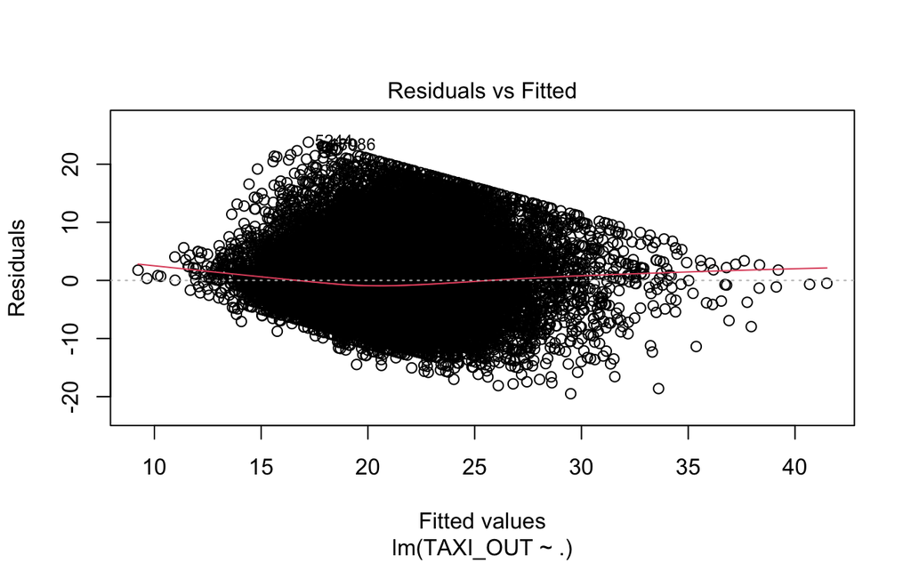

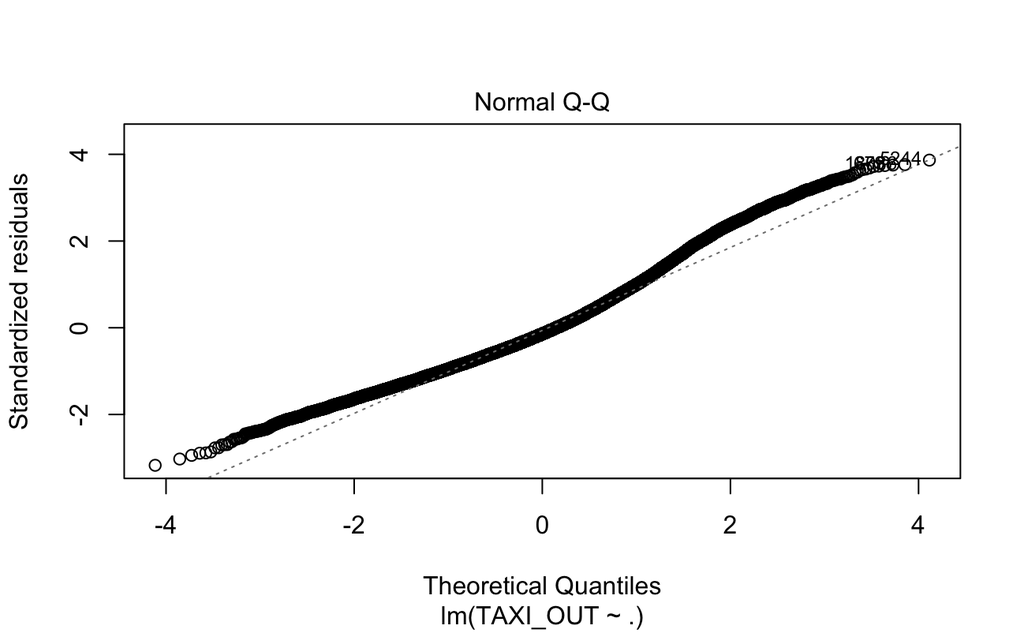

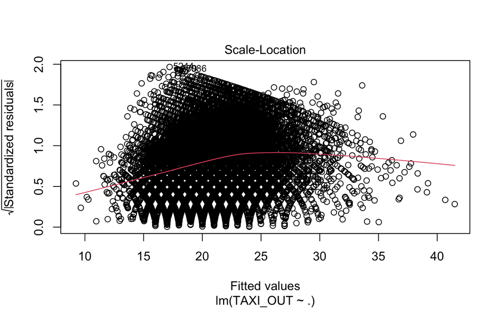

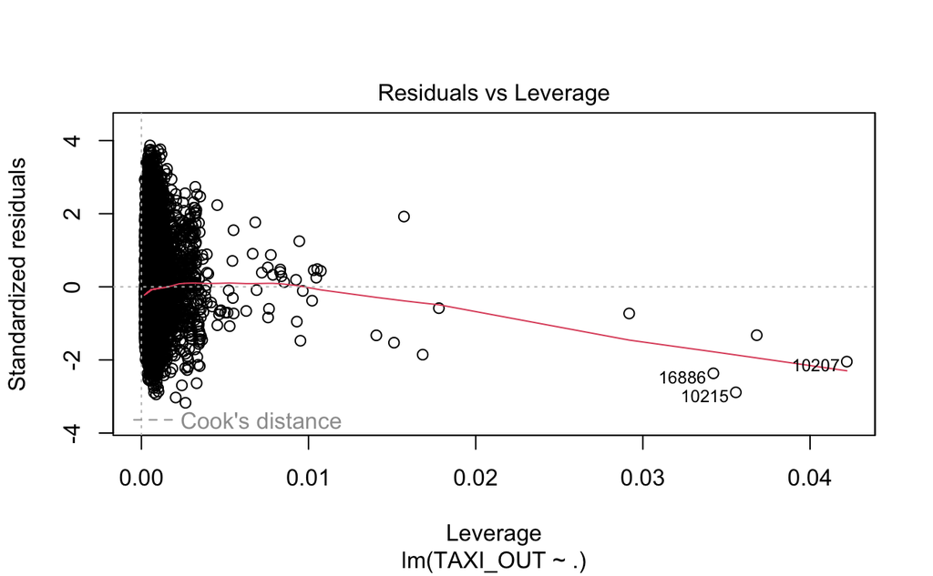

```r
defaultpred
```

[output not shown]

[output cut: 320 more lines]

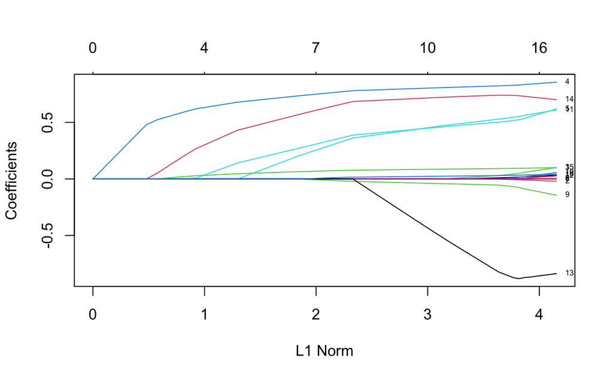

```r
xrtrain <- as.matrix(subset(pValueTrain3, select = -c(TAXI_OUT)))
yrtrain <- as.matrix(pValueTrain3$TAXI_OUT)
p_LassoModel <- glmnet(xrtrain, yrtrain)
plot(p_LassoModel,label = TRUE)
```

```r
coef.glmnet(p_LassoModel, s= 0.1)
```

```
17 x 1 sparse Matrix of class "dgCMatrix"
                        s1
(Intercept)  -9.7694448377
MONTH         0.0135226131
DAY_OF_MONTH -0.0053178927
DAY_OF_WEEK   0.0436287586
TAIL_NUM      0.8278905742
DEST          0.5165062288
DEP_DELAY     0.0020361713
DISTANCE      .
CRS_DEP_M     0.0007343802
Temperature  -0.0685042360
Dew.Point     0.0080716290
Wind          0.5453753361
Wind.Speed    .
Pressure     -0.8727298338
Condition     0.7386794859
sch_dep       0.0932992147
sch_arr       0.0319155649
```

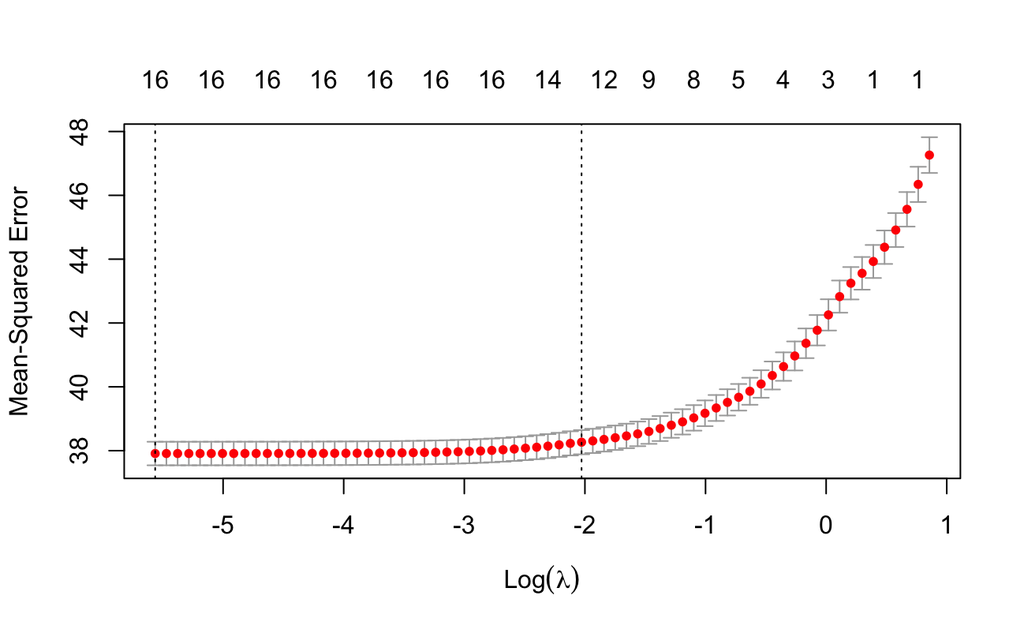

```r
cvmodelL <- cv.glmnet(xrtrain, yrtrain, type.measure = "mse", nfolds = 20)
plot(cvmodelL)
```

```r
xrtest <- as.matrix(subset(test, select = -c(TAXI_OUT, OP_UNIQUE_CARRIER, CRS_ELAPSED_TIME, DEP_TIME_M, CRS_ARR_M, Humidity, Wind.Gust)))
yrtest <- as.matrix(test$TAXI_OUT)

defaultpred <- predict(fullModel, newdata = test ,interval="confidence")
MSE0  <- mean((test$TAXI_OUT - defaultpred)^2)
predL <- predict(p_LassoModel, newx = xrtest, s=cvmodelL$lambda.min)
MSEL  <- mean((test$TAXI_OUT - predL)^2)

print(MSE0)
```

```
[1] 40.25879
```

```r
print(MSEL)
```

```
[1] NaN
```

Dropping features based off of the lasso regression:

```r
lassoDropDF <- subset(pValueTrain3, select=-c(DISTANCE, Wind.Speed))
lassoDropModel <- lm(TAXI_OUT ~ ., data=lassoDropDF)
summary(lassoDropModel)
```

```
Call:
lm(formula = TAXI_OUT ~ ., data = lassoDropDF)

Residuals:
     Min       1Q   Median       3Q      Max
-19.7939  -4.3502  -0.8738   3.5847  23.9394

Coefficients:
               Estimate Std. Error t value Pr(>|t|)
(Intercept)  -5.4448973  4.9436101  -1.101 0.270732
MONTH         0.0336973  0.0077805   4.331 1.49e-05 ***
DAY_OF_MONTH -0.0221494  0.0044712  -4.954 7.32e-07 ***
DAY_OF_WEEK   0.1109072  0.0196483   5.645 1.67e-08 ***
TAIL_NUM      0.8541521  0.0167868  50.882  < 2e-16 ***
DEST          0.5893918  0.0329741  17.874  < 2e-16 ***
DEP_DELAY     0.0036295  0.0009911   3.662 0.000251 ***
CRS_DEP_M     0.0010808  0.0001496   7.226 5.11e-13 ***
Temperature  -0.1382094  0.0081589 -16.940  < 2e-16 ***
Dew.Point     0.0482605  0.0055457   8.702  < 2e-16 ***
Wind          0.6247629  0.0499022  12.520  < 2e-16 ***
Pressure     -1.1132516  0.1531596  -7.269 3.74e-13 ***
Condition     0.7317308  0.0332741  21.991  < 2e-16 ***
sch_dep       0.1003291  0.0040987  24.478  < 2e-16 ***
sch_arr       0.0433095  0.0053788   8.052 8.50e-16 ***
---
Signif. codes:  0 ‘***’ 0.001 ‘**’ 0.01 ‘*’ 0.05 ‘.’ 0.1 ‘ ’ 1

Residual standard error: 6.157 on 25865 degrees of freedom
Multiple R-squared:  0.1987,    Adjusted R-squared:  0.1983
F-statistic: 458.2 on 14 and 25865 DF,  p-value: < 2.2e-16
```

```r
summary(lassoDropModel2)
```

```
Call:
lm(formula = TAXI_OUT ~ 0 + ., data = lassoDropDF)

Residuals:
     Min       1Q   Median       3Q      Max
-19.8029  -4.3515  -0.8757   3.5827  23.9565

Coefficients:
               Estimate Std. Error t value Pr(>|t|)
MONTH         0.0335080  0.0077786   4.308 1.66e-05 ***
DAY_OF_MONTH -0.0224243  0.0044642  -5.023 5.12e-07 ***
DAY_OF_WEEK   0.1123697  0.0196034   5.732 1.00e-08 ***
TAIL_NUM      0.8533792  0.0167722  50.880  < 2e-16 ***
DEST          0.5848543  0.0327158  17.877  < 2e-16 ***
DEP_DELAY     0.0035627  0.0009893   3.601 0.000317 ***
CRS_DEP_M     0.0010797  0.0001496   7.219 5.39e-13 ***
Temperature  -0.1390914  0.0081195 -17.131  < 2e-16 ***
Dew.Point     0.0469412  0.0054148   8.669  < 2e-16 ***
Wind          0.6178888  0.0495106  12.480  < 2e-16 ***
Pressure     -1.2751293  0.0430859 -29.595  < 2e-16 ***
Condition     0.7200405  0.0315360  22.832  < 2e-16 ***
sch_dep       0.1005402  0.0040942  24.557  < 2e-16 ***
sch_arr       0.0431896  0.0053777   8.031 1.01e-15 ***
---
Signif. codes:  0 ‘***’ 0.001 ‘**’ 0.01 ‘*’ 0.05 ‘.’ 0.1 ‘ ’ 1

Residual standard error: 6.157 on 25866 degrees of freedom
Multiple R-squared:  0.9216,    Adjusted R-squared:  0.9216
F-statistic: 2.172e+04 on 14 and 25866 DF,  p-value: < 2.2e-16
```

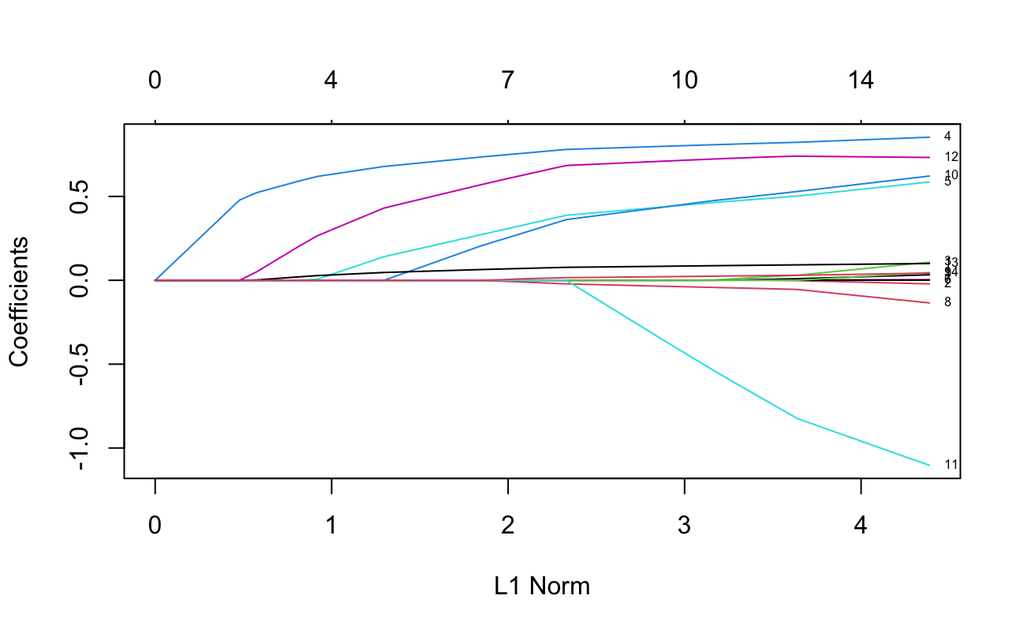

```r
xrtrain <- as.matrix(subset(lassoDropDF, select = -c(TAXI_OUT)))
yrtrain <- as.matrix(lassoDropDF$TAXI_OUT)
p_LassoModel <- glmnet(xrtrain, yrtrain)
plot(p_LassoModel,label = TRUE)
```

```r
coef.glmnet(p_LassoModel, s= 0.1)
```

```
15 x 1 sparse Matrix of class "dgCMatrix"
                        s1
(Intercept)  -9.7694448377
MONTH         0.0135226131
DAY_OF_MONTH -0.0053178927
DAY_OF_WEEK   0.0436287586
TAIL_NUM      0.8278905742
DEST          0.5165062288
DEP_DELAY     0.0020361713
CRS_DEP_M     0.0007343802
Temperature  -0.0685042360
Dew.Point     0.0080716290
Wind          0.5453753361
Pressure     -0.8727298338
Condition     0.7386794859
sch_dep       0.0932992147
sch_arr       0.0319155649
```

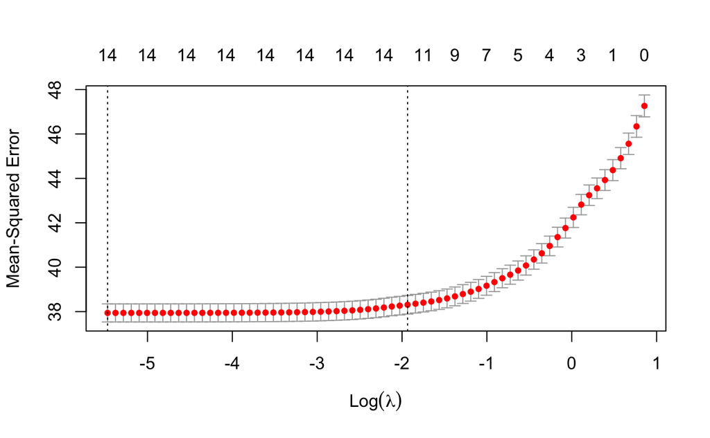

```r
cvmodelL <- cv.glmnet(xrtrain, yrtrain, type.measure = "mse", nfolds = 20)
plot(cvmodelL)
```

```r
xrtest <- as.matrix(subset(test, select = -c(TAXI_OUT, OP_UNIQUE_CARRIER, CRS_ELAPSED_TIME, DEP_TIME_M, CRS_ARR_M, Humidity, Wind.Gust, DISTANCE, Wind.Speed)))
yrtest <- as.matrix(test$TAXI_OUT)

defaultpred <- predict(fullModel, newdata = test ,interval="confidence")
MSE0  <- mean((test$TAXI_OUT - defaultpred)^2)
predL <- predict(p_LassoModel, newx = xrtest, s=cvmodelL$lambda.min)
MSEL  <- mean((test$TAXI_OUT - predL)^2)

print(MSE0)
```

```
[1] 40.25879
```

```r
print(MSEL)
```

```
[1] NaN
```

```r
conditions <- unique(df$Condition)

for (condition in conditions) {
  train$Condition[train$Condition == condition] <- mean(train$TAXI_OUT[train$Condition == condition])
  test$Condition[test$Condition == condition] <- mean(train$TAXI_OUT[train$Condition == condition])
}

train$Condition <- as.numeric(train$Condition)
test$Condition <- as.numeric(test$Condition)
```

Creating dummy variables for flight carriers AS, B6, and AA

```r
train$is_AS <- ifelse(train$OP_UNIQUE_CARRIER == 'AS', 1, 0)
test$is_AS <- ifelse(test$OP_UNIQUE_CARRIER == 'AS', 1, 0)

train$is_B6 <- ifelse(train$OP_UNIQUE_CARRIER == 'B6', 1, 0)
test$is_B6 <- ifelse(test$OP_UNIQUE_CARRIER == 'B6', 1, 0)

train$is_AA <- ifelse(train$OP_UNIQUE_CARRIER == 'AA', 1, 0)
test$is_AA <- ifelse(test$OP_UNIQUE_CARRIER == 'AA', 1, 0)

head(test)
```

|  | MONTH | DAY_OF_MONTH | DAY_OF_WEEK | OP_UNIQUE_CARRIER | TAIL_NUM | DEST | DEP_DELAY | CRS_ELAPSED_TIME | DISTANCE | CRS_DEP_M | DEP_TIME_M | CRS_ARR_M | Temperature | Dew.Point | Humidity | Wind | Wind.Speed | Wind.Gust | Pressure | Condition | sch_dep | sch_arr | TAXI_OUT | is_AS | is_B6 | is_AA |
| --- | --- | --- | --- | --- | --- | --- | --- | --- | --- | --- | --- | --- | --- | --- | --- | --- | --- | --- | --- | --- | --- | --- | --- | --- | --- | --- |
| 4 | 11 | 1 | 5 | B6 | N999JQ | MCO | -2 | 168 | 944 | 345 | 343 | 513 | 48 | 34 | 58 | W | 25 | 38 | 29.86 | Fair / Windy | 9 | 17 | 12 | 0 | 1 | 0 |
| 7 | 11 | 1 | 5 | AA | N107NN | LAX | -1 | 373 | 2475 | 360 | 359 | 553 | 46 | 32 | 58 | W | 24 | 35 | 29.91 | Fair / Windy | 9 | 17 | 26 | 0 | 0 | 1 |
| 18 | 11 | 1 | 5 | DL | N362NB | BOS | -5 | 82 | 187 | 420 | 415 | 502 | 47 | 33 | 59 | W | 24 | 29 | 30.00 | Fair / Windy | 17 | 21 | 15 | 0 | 0 | 0 |
| 21 | 11 | 1 | 5 | B6 | N292JB | SYR | -3 | 73 | 209 | 420 | 417 | 493 | 47 | 33 | 59 | W | 24 | 29 | 30.00 | Fair / Windy | 17 | 21 | 21 | 0 | 1 | 0 |
| 61 | 11 | 1 | 5 | B6 | N986JB | LAX | -4 | 379 | 2475 | 515 | 511 | 714 | 50 | 33 | 52 | W | 21 | 30 | 30.00 | Fair / Windy | 46 | 19 | 25 | 0 | 1 | 0 |
| 80 | 11 | 1 | 5 | B6 | N587JB | AUS | 54 | 254 | 1521 | 502 | 556 | 696 | 52 | 32 | 47 | WNW | 25 | 32 | 30.02 | Fair / Windy | 30 | 18 | 10 | 0 | 1 | 0 |

```r
unique(train$Condition)
```

```
 [1] "Fair / Windy"          "Fair"                  "Light Rain / Windy"
 [4] "Partly Cloudy"         "Mostly Cloudy"         "Cloudy"
 [7] "Light Rain"            "Mostly Cloudy / Windy" "Partly Cloudy / Windy"
[10] "Light Snow / Windy"    "Cloudy / Windy"        "Light Drizzle"
[13] "Rain"                  "Heavy Rain"            "Fog"
[16] "Wintry Mix"            "Light Freezing Rain"   "Light Snow"
[19] "Wintry Mix / Windy"    "Fog / Windy"           "Light Drizzle / Windy"
[22] "Rain / Windy"          "Drizzle and Fog"       "Snow"
[25] "Heavy Rain / Windy"
```

Creating dummy variables for Conditions

```r
train$is_heavyrain.windy <- ifelse(train$Condition == 'Heavy Rain / Windy', 1, 0)
test$is_heavyrain.windy <- ifelse(test$Condition == 'Heavy Rain / Windy', 1, 0)

train$is_fog.windy <- ifelse(train$Condition == 'Fog / Windy', 1, 0)
test$is_fog.windy <- ifelse(test$Condition == 'Fog / Windy', 1, 0)

train$is_drizzle.fog <- ifelse(train$Condition == 'Drizzle and Fog', 1, 0)
test$is_drizzle.fog <- ifelse(test$Condition == 'Drizzle and Fog', 1, 0)

train$is_light.snow <- ifelse(train$Condition == 'Light Snow', 1, 0)
test$is_light.snow <- ifelse(test$Condition == 'Light Snow', 1, 0)

train$is_lightdrizzle.windy <- ifelse(train$Condition == 'Light Drizzle / Windy', 1, 0)
test$is_lightdrizzle.windy <- ifelse(test$Condition == 'Light Drizzle / Windy', 1, 0)

train$is_lightfreezingrain <- ifelse(train$Condition == 'Light Freezing Rain', 1, 0)
test$is_lightfreezingrain <- ifelse(test$Condition == 'Light Freezing Rain', 1, 0)

train$is_snow <- ifelse(train$Condition == 'Snow', 1, 0)
test$is_snow <- ifelse(test$Condition == 'Snow', 1, 0)

train$is_wintrymix.windy <- ifelse(train$Condition == 'Wintry Mix / Windy', 1, 0)
test$is_wintrymix.windy <- ifelse(test$Condition == 'Wintry Mix / Windy', 1, 0)
```

```r
colnames(train_with_dummies)
```

```
 [1] "MONTH"                 "DAY_OF_MONTH"          "DAY_OF_WEEK"
 [4] "DEP_DELAY"             "CRS_ELAPSED_TIME"      "DISTANCE"
 [7] "CRS_DEP_M"             "DEP_TIME_M"            "CRS_ARR_M"
[10] "Temperature"           "Dew.Point"             "Humidity"
[13] "Wind.Speed"            "Wind.Gust"             "Pressure"
[16] "sch_dep"               "sch_arr"               "TAXI_OUT"
[19] "is_AS"                 "is_B6"                 "is_AA"
[22] "is_heavyrain.windy"    "is_fog.windy"          "is_drizzle.fog"
[25] "is_light.snow"         "is_lightdrizzle.windy" "is_lightfreezingrain"
[28] "is_snow"               "is_wintrymix.windy"
```

```r
model_with_dummies <- lm(TAXI_OUT ~ ., data=train_with_dummies)
summary(model_with_dummies)
```

```
Call:
lm(formula = TAXI_OUT ~ ., data = train_with_dummies)

Residuals:
    Min      1Q  Median      3Q     Max
-19.511  -4.617  -1.064   3.777  24.026

Coefficients:
                        Estimate Std. Error t value Pr(>|t|)
(Intercept)            4.323e+01  5.470e+00   7.903 2.82e-15 ***
MONTH                  4.205e-02  8.290e-03   5.072 3.95e-07 ***
DAY_OF_MONTH          -2.296e-02  4.723e-03  -4.862 1.17e-06 ***
DAY_OF_WEEK            1.220e-01  2.079e-02   5.867 4.48e-09 ***
DEP_DELAY              3.997e-03  1.046e-03   3.820 0.000134 ***
CRS_ELAPSED_TIME       6.159e-04  3.780e-03   0.163 0.870558
DISTANCE               1.987e-04  5.068e-04   0.392 0.695063
CRS_DEP_M              3.609e-04  4.365e-04   0.827 0.408390
DEP_TIME_M             9.789e-04  4.391e-04   2.229 0.025807 *
CRS_ARR_M             -4.331e-05  1.434e-04  -0.302 0.762614
Temperature           -2.252e-01  8.932e-03 -25.217  < 2e-16 ***
Dew.Point              1.266e-01  6.588e-03  19.217  < 2e-16 ***
Humidity              -1.391e-02  1.813e-03  -7.675 1.72e-14 ***
Wind.Speed             6.165e-03  9.732e-03   0.634 0.526375
Wind.Gust              6.323e-02  4.792e-03  13.194  < 2e-16 ***
Pressure              -7.558e-01  1.793e-01  -4.216 2.50e-05 ***
sch_dep                1.145e-01  4.538e-03  25.240  < 2e-16 ***
sch_arr                4.278e-02  6.091e-03   7.024 2.22e-12 ***
is_AS                  3.954e+00  2.288e-01  17.285  < 2e-16 ***
is_B6                 -1.674e+00  1.011e-01 -16.553  < 2e-16 ***
is_AA                 -6.447e-01  1.343e-01  -4.802 1.58e-06 ***
is_heavyrain.windy    -7.722e+00  2.903e+00  -2.660 0.007811 **
is_fog.windy          -5.268e+00  1.309e+00  -4.025 5.71e-05 ***
is_drizzle.fog         1.356e+01  3.255e+00   4.165 3.13e-05 ***
is_light.snow          8.667e+00  7.905e-01  10.964  < 2e-16 ***
is_lightdrizzle.windy  6.606e+00  1.579e+00   4.183 2.89e-05 ***
is_lightfreezingrain   8.764e+00  3.242e+00   2.703 0.006871 **
is_snow                1.232e+01  4.582e+00   2.689 0.007166 **
is_wintrymix.windy     1.477e+01  3.743e+00   3.948 7.91e-05 ***
---
Signif. codes:  0 ‘***’ 0.001 ‘**’ 0.01 ‘*’ 0.05 ‘.’ 0.1 ‘ ’ 1

Residual standard error: 6.474 on 25851 degrees of freedom
Multiple R-squared:  0.1146,    Adjusted R-squared:  0.1136
F-statistic: 119.4 on 28 and 25851 DF,  p-value: < 2.2e-16
```

```r
stepModel <- step(model_with_dummies)
```

```
Start:  AIC=96702.62
TAXI_OUT ~ MONTH + DAY_OF_MONTH + DAY_OF_WEEK + DEP_DELAY + CRS_ELAPSED_TIME +
    DISTANCE + CRS_DEP_M + DEP_TIME_M + CRS_ARR_M + Temperature +
    Dew.Point + Humidity + Wind.Speed + Wind.Gust + Pressure +
    sch_dep + sch_arr + is_AS + is_B6 + is_AA + is_heavyrain.windy +
    is_fog.windy + is_drizzle.fog + is_light.snow + is_lightdrizzle.windy +
    is_lightfreezingrain + is_snow + is_wintrymix.windy

                        Df Sum of Sq     RSS   AIC
- CRS_ELAPSED_TIME       1       1.1 1083344 96701
- CRS_ARR_M              1       3.8 1083346 96701
- DISTANCE               1       6.4 1083349 96701
- Wind.Speed             1      16.8 1083359 96701
- CRS_DEP_M              1      28.6 1083371 96701
<none>                               1083343 96703
- DEP_TIME_M             1     208.3 1083551 96706
- is_heavyrain.windy     1     296.6 1083639 96708
- is_snow                1     303.1 1083646 96708
- is_lightfreezingrain   1     306.2 1083649 96708
- DEP_DELAY              1     611.5 1083954 96715
- is_wintrymix.windy     1     653.1 1083996 96716
- is_fog.windy           1     679.0 1084022 96717
- is_drizzle.fog         1     726.8 1084069 96718
- is_lightdrizzle.windy  1     733.3 1084076 96718
- Pressure               1     744.9 1084088 96718
- is_AA                  1     966.3 1084309 96724
- DAY_OF_MONTH           1     990.6 1084333 96724
- MONTH                  1    1078.3 1084421 96726
- DAY_OF_WEEK            1    1442.6 1084785 96735
- sch_arr                1    2067.3 1085410 96750
- Humidity               1    2468.3 1085811 96760
- is_light.snow          1    5037.5 1088380 96821
- Wind.Gust              1    7295.4 1090638 96874
- is_B6                  1   11482.6 1094825 96973
- is_AS                  1   12520.4 1095863 96998
- Dew.Point              1   15476.3 1098819 97068
- Temperature            1   26647.9 1109991 97330
- sch_dep                1   26696.9 1110040 97331

Step:  AIC=96700.65
```

[output cut: 128 more lines]

```
- is_AA                  1     977.9 1084369 96717
- DAY_OF_MONTH           1    1008.1 1084399 96718
- MONTH                  1    1088.7 1084480 96720
- DISTANCE               1    1360.2 1084751 96726
- DAY_OF_WEEK            1    1454.3 1084845 96728
- sch_arr                1    2162.2 1085553 96745
- Humidity               1    2438.4 1085829 96752
- DEP_TIME_M             1    2810.5 1086201 96761
- is_light.snow          1    5040.6 1088431 96814
- is_AS                  1   12621.3 1096012 96994
- Wind.Gust              1   12792.9 1096184 96998
- is_B6                  1   13358.0 1096749 97011
- Dew.Point              1   16658.0 1100049 97089
- Temperature            1   27967.2 1111358 97353
- sch_dep                1   28191.8 1111583 97359
```

```r
summary(stepModel)
```

```
Call:
lm(formula = TAXI_OUT ~ MONTH + DAY_OF_MONTH + DAY_OF_WEEK +
    DEP_DELAY + DISTANCE + DEP_TIME_M + Temperature + Dew.Point +
    Humidity + Wind.Gust + Pressure + sch_dep + sch_arr + is_AS +
    is_B6 + is_AA + is_heavyrain.windy + is_fog.windy + is_drizzle.fog +
    is_light.snow + is_lightdrizzle.windy + is_lightfreezingrain +
    is_snow + is_wintrymix.windy, data = train_with_dummies)

Residuals:
    Min      1Q  Median      3Q     Max
-19.523  -4.614  -1.066   3.786  24.003

Coefficients:
                        Estimate Std. Error t value Pr(>|t|)
(Intercept)            4.447e+01  5.114e+00   8.697  < 2e-16 ***
MONTH                  4.172e-02  8.184e-03   5.097 3.47e-07 ***
DAY_OF_MONTH          -2.312e-02  4.713e-03  -4.905 9.40e-07 ***
DAY_OF_WEEK            1.224e-01  2.078e-02   5.891 3.88e-09 ***
DEP_DELAY              4.082e-03  1.041e-03   3.921 8.84e-05 ***
DISTANCE               2.794e-04  4.904e-05   5.697 1.23e-08 ***
DEP_TIME_M             1.304e-03  1.592e-04   8.190 2.74e-16 ***
Temperature           -2.247e-01  8.696e-03 -25.835  < 2e-16 ***
Dew.Point              1.256e-01  6.302e-03  19.938  < 2e-16 ***
Humidity              -1.381e-02  1.810e-03  -7.628 2.46e-14 ***
Wind.Gust              6.514e-02  3.728e-03  17.473  < 2e-16 ***
Pressure              -7.928e-01  1.684e-01  -4.708 2.51e-06 ***
sch_dep                1.141e-01  4.398e-03  25.938  < 2e-16 ***
sch_arr                4.210e-02  5.861e-03   7.183 6.99e-13 ***
is_AS                  3.953e+00  2.278e-01  17.355  < 2e-16 ***
is_B6                 -1.672e+00  9.366e-02 -17.855  < 2e-16 ***
is_AA                 -6.415e-01  1.328e-01  -4.831 1.37e-06 ***
is_heavyrain.windy    -7.693e+00  2.902e+00  -2.651  0.00803 **
is_fog.windy          -5.221e+00  1.306e+00  -3.998 6.40e-05 ***
is_drizzle.fog         1.348e+01  3.252e+00   4.144 3.42e-05 ***
is_light.snow          8.666e+00  7.902e-01  10.968  < 2e-16 ***
is_lightdrizzle.windy  6.610e+00  1.579e+00   4.186 2.85e-05 ***
is_lightfreezingrain   8.846e+00  3.240e+00   2.730  0.00633 **
is_snow                1.235e+01  4.581e+00   2.696  0.00702 **
is_wintrymix.windy     1.475e+01  3.742e+00   3.942 8.09e-05 ***
---
Signif. codes:  0 ‘***’ 0.001 ‘**’ 0.01 ‘*’ 0.05 ‘.’ 0.1 ‘ ’ 1

Residual standard error: 6.473 on 25855 degrees of freedom
Multiple R-squared:  0.1145,    Adjusted R-squared:  0.1137
F-statistic: 139.3 on 24 and 25855 DF,  p-value: < 2.2e-16
```

```r
vif(stepModel)
```

```
                MONTH          DAY_OF_MONTH           DAY_OF_WEEK             DEP_DELAY
             1.032427              1.050975              1.052173              1.030891
             DISTANCE            DEP_TIME_M           Temperature             Dew.Point
             1.175268              1.463948              3.028346              3.719590
             Humidity             Wind.Gust              Pressure               sch_dep
             1.115451              1.214097              1.539401              1.080601
              sch_arr                 is_AS                 is_B6                 is_AA
             1.448077              1.159450              1.202145              1.187625
   is_heavyrain.windy          is_fog.windy        is_drizzle.fog         is_light.snow
             1.004649              1.016190              1.009230              1.010552
is_lightdrizzle.windy  is_lightfreezingrain               is_snow    is_wintrymix.windy
             1.010781              1.001840              1.001622              1.002527
```

[1] “MONTH” “DAY_OF_MONTH” “DAY_OF_WEEK”  
[4] “DEP_DELAY” “CRS_ELAPSED_TIME” “DISTANCE”  
[7] “CRS_DEP_M” “DEP_TIME_M” “CRS_ARR_M”  
[10] “Temperature” “Dew.Point” “Humidity”  
[13] “Wind.Speed” “Wind.Gust” “Pressure”  
[16] “sch_dep” “sch_arr” “TAXI_OUT”  
[19] “is_AS” “is_B6” “is_AA”  
[22] “is_heavyrain.windy” “is_fog.windy” “is_drizzle.fog”  
[25] “is_light.snow” “is_lightdrizzle.windy” “is_lightfreezingrain” [28] “is_snow” “is_wintrymix.windy”

TAXI_OUT ~ MONTH + DAY_OF_MONTH + DAY_OF_WEEK + DEP_DELAY + DISTANCE + DEP_TIME_M + Temperature + Dew.Point + Humidity + Wind.Gust + Pressure + sch_dep + sch_arr + is_AS + is_B6 + is_AA + is_heavyrain.windy + is_fog.windy + is_drizzle.fog + is_light.snow + is_lightdrizzle.windy + is_lightfreezingrain + is_snow + is_wintrymix.windy

```r
coef.glmnet(lassoModel, s= 0.1)
```

```
25 x 1 sparse Matrix of class "dgCMatrix"
                                 s1
(Intercept)           44.9732552195
MONTH                  0.0210276681
DAY_OF_MONTH          -0.0097375759
DAY_OF_WEEK            0.0508380383
DEP_DELAY              0.0025085150
DISTANCE               0.0001378908
DEP_TIME_M             0.0009804878
Temperature           -0.1423676404
Dew.Point              0.0696962461
Humidity              -0.0060818238
Wind.Gust              0.0527364649
Pressure              -0.8458992868
sch_dep                0.1112271221
sch_arr                0.0290026128
is_AS                  3.7836870880
is_B6                 -1.3235509029
is_AA                 -0.1622019969
is_heavyrain.windy     .
is_fog.windy          -1.0009530022
is_drizzle.fog         3.8689203450
is_light.snow          7.1100782428
is_lightdrizzle.windy  2.8073136002
is_lightfreezingrain   1.4597625817
is_snow                1.4570709585
is_wintrymix.windy     6.6969189049
```

Eliminating features based on Lasso coefficients, if coefficient is equal to . or less than 0.01, we eliminate the feature.

|  | MONTH | DAY_OF_WEEK | Temperature | Dew.Point | Wind.Gust | Pressure | sch_dep | sch_arr | is_AS | is_B6 | is_AA | is_fog.windy | is_drizzle.fog | is_light.snow | is_lightdrizzle.windy | is_lightfreezingrain | is_snow | is_wintrymix.windy | TAXI_OUT |
| --- | --- | --- | --- | --- | --- | --- | --- | --- | --- | --- | --- | --- | --- | --- | --- | --- | --- | --- | --- |
| 1 | 11 | 5 | 48 | 34 | 38 | 29.86 | 9 | 17 | 0 | 1 | 0 | 0 | 0 | 0 | 0 | 0 | 0 | 0 | 14 |
| 2 | 11 | 5 | 48 | 34 | 38 | 29.86 | 9 | 17 | 0 | 1 | 0 | 0 | 0 | 0 | 0 | 0 | 0 | 0 | 15 |
| 3 | 11 | 5 | 48 | 34 | 38 | 29.86 | 9 | 17 | 0 | 1 | 0 | 0 | 0 | 0 | 0 | 0 | 0 | 0 | 22 |
| 5 | 11 | 5 | 46 | 32 | 35 | 29.91 | 9 | 17 | 0 | 0 | 0 | 0 | 0 | 0 | 0 | 0 | 0 | 0 | 13 |
| 6 | 11 | 5 | 46 | 32 | 35 | 29.91 | 9 | 17 | 0 | 0 | 1 | 0 | 0 | 0 | 0 | 0 | 0 | 0 | 21 |
| 8 | 11 | 5 | 46 | 32 | 35 | 29.91 | 17 | 21 | 0 | 1 | 0 | 0 | 0 | 0 | 0 | 0 | 0 | 0 | 11 |

```r
summary(modelAfterLasso)
```

```
Call:
lm(formula = TAXI_OUT ~ ., data = newFeatures)

Residuals:
    Min      1Q  Median      3Q     Max
-19.537  -4.647  -1.082   3.778  23.359

Coefficients:
                       Estimate Std. Error t value Pr(>|t|)
(Intercept)           49.969008   5.081072   9.834  < 2e-16 ***
MONTH                  0.044282   0.008204   5.397 6.82e-08 ***
DAY_OF_WEEK            0.115726   0.020851   5.550 2.88e-08 ***
Temperature           -0.202493   0.008463 -23.926  < 2e-16 ***
Dew.Point              0.107539   0.006065  17.730  < 2e-16 ***
Wind.Gust              0.066401   0.003726  17.819  < 2e-16 ***
Pressure              -1.003913   0.167033  -6.010 1.88e-09 ***
sch_dep                0.116176   0.004381  26.518  < 2e-16 ***
sch_arr                0.065163   0.004948  13.170  < 2e-16 ***
is_AS                  4.246380   0.216376  19.625  < 2e-16 ***
is_B6                 -1.573956   0.092365 -17.041  < 2e-16 ***
is_AA                 -0.512715   0.129576  -3.957 7.61e-05 ***
is_fog.windy          -4.604329   1.307758  -3.521 0.000431 ***
is_drizzle.fog        13.909219   3.264661   4.261 2.05e-05 ***
is_light.snow          8.795015   0.792703  11.095  < 2e-16 ***
is_lightdrizzle.windy  5.826427   1.582756   3.681 0.000233 ***
is_lightfreezingrain   9.450220   3.252017   2.906 0.003664 **
is_snow               12.220632   4.599708   2.657 0.007893 **
is_wintrymix.windy    15.234910   3.756523   4.056 5.02e-05 ***
---
Signif. codes:  0 ‘***’ 0.001 ‘**’ 0.01 ‘*’ 0.05 ‘.’ 0.1 ‘ ’ 1

Residual standard error: 6.5 on 25861 degrees of freedom
Multiple R-squared:  0.107, Adjusted R-squared:  0.1064
F-statistic: 172.2 on 18 and 25861 DF,  p-value: < 2.2e-16
```

```r
summary(stepModel2)
```

```
Call:
lm(formula = TAXI_OUT ~ MONTH + DAY_OF_WEEK + Temperature + Dew.Point +
    Wind.Gust + Pressure + sch_dep + sch_arr + is_AS + is_B6 +
    is_AA + is_fog.windy + is_drizzle.fog + is_light.snow + is_lightdrizzle.windy +
    is_lightfreezingrain + is_snow + is_wintrymix.windy, data = newFeatures)

Residuals:
    Min      1Q  Median      3Q     Max
-19.537  -4.647  -1.082   3.778  23.359

Coefficients:
                       Estimate Std. Error t value Pr(>|t|)
(Intercept)           49.969008   5.081072   9.834  < 2e-16 ***
MONTH                  0.044282   0.008204   5.397 6.82e-08 ***
DAY_OF_WEEK            0.115726   0.020851   5.550 2.88e-08 ***
Temperature           -0.202493   0.008463 -23.926  < 2e-16 ***
Dew.Point              0.107539   0.006065  17.730  < 2e-16 ***
Wind.Gust              0.066401   0.003726  17.819  < 2e-16 ***
Pressure              -1.003913   0.167033  -6.010 1.88e-09 ***
sch_dep                0.116176   0.004381  26.518  < 2e-16 ***
sch_arr                0.065163   0.004948  13.170  < 2e-16 ***
is_AS                  4.246380   0.216376  19.625  < 2e-16 ***
is_B6                 -1.573956   0.092365 -17.041  < 2e-16 ***
is_AA                 -0.512715   0.129576  -3.957 7.61e-05 ***
is_fog.windy          -4.604329   1.307758  -3.521 0.000431 ***
is_drizzle.fog        13.909219   3.264661   4.261 2.05e-05 ***
is_light.snow          8.795015   0.792703  11.095  < 2e-16 ***
is_lightdrizzle.windy  5.826427   1.582756   3.681 0.000233 ***
is_lightfreezingrain   9.450220   3.252017   2.906 0.003664 **
is_snow               12.220632   4.599708   2.657 0.007893 **
is_wintrymix.windy    15.234910   3.756523   4.056 5.02e-05 ***
---
Signif. codes:  0 ‘***’ 0.001 ‘**’ 0.01 ‘*’ 0.05 ‘.’ 0.1 ‘ ’ 1

Residual standard error: 6.5 on 25861 degrees of freedom
Multiple R-squared:  0.107, Adjusted R-squared:  0.1064
F-statistic: 172.2 on 18 and 25861 DF,  p-value: < 2.2e-16
```

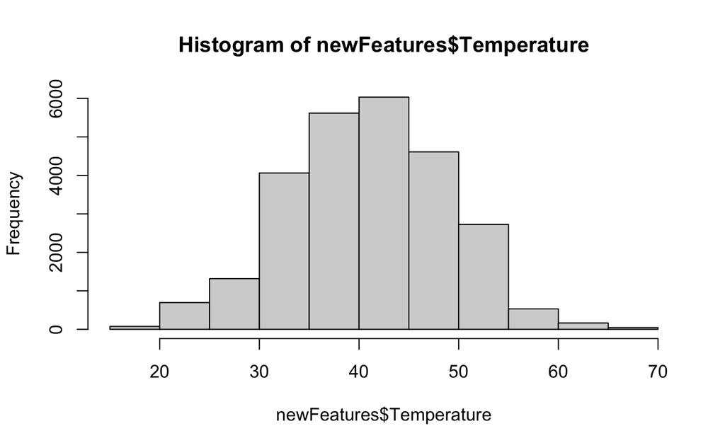

```r
hist(newFeatures$Temperature)
```

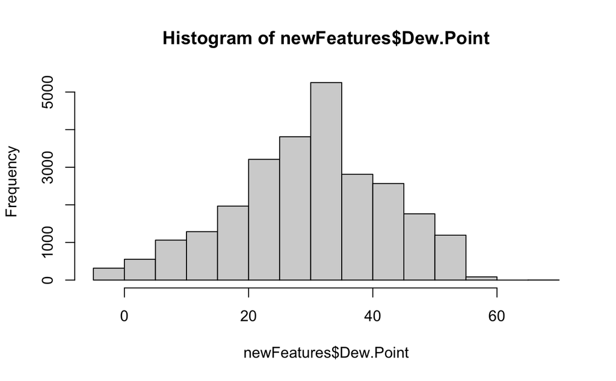

```r
hist(newFeatures$Dew.Point)
```

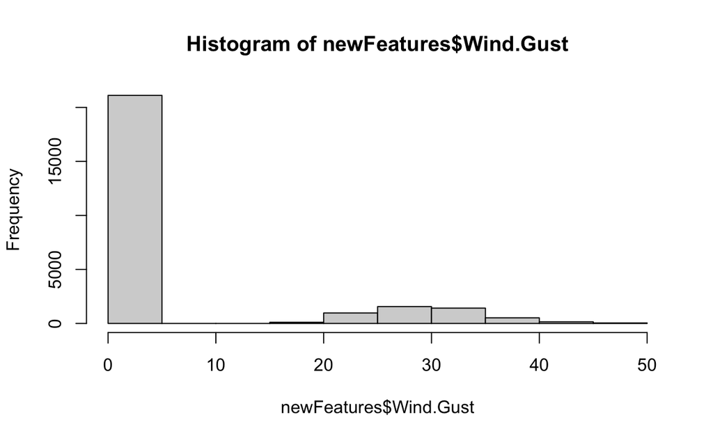

```r
hist(newFeatures$Wind.Gust)
```

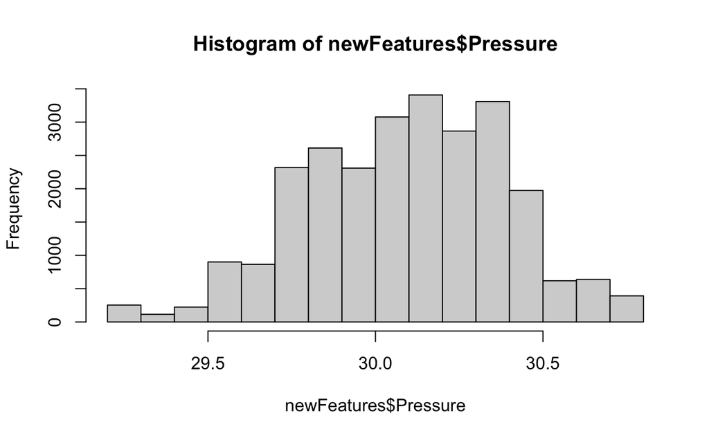

```r
hist(newFeatures$Pressure)
```

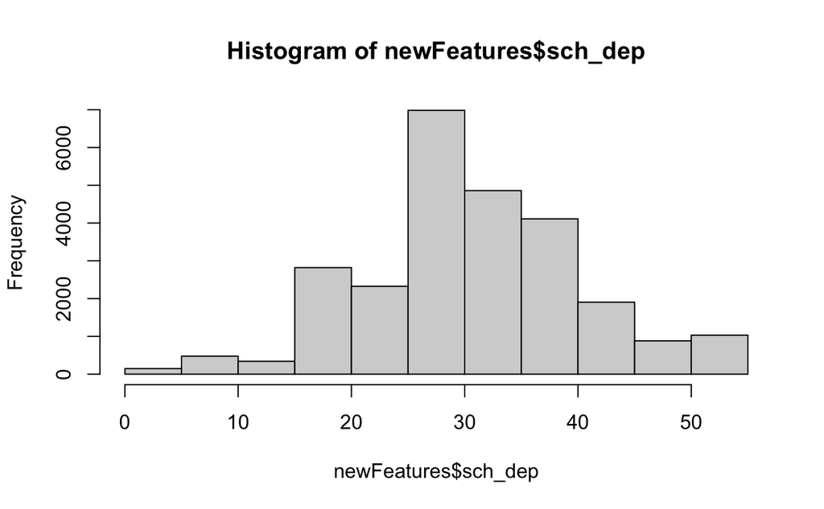

```r
hist(newFeatures$sch_dep)
```

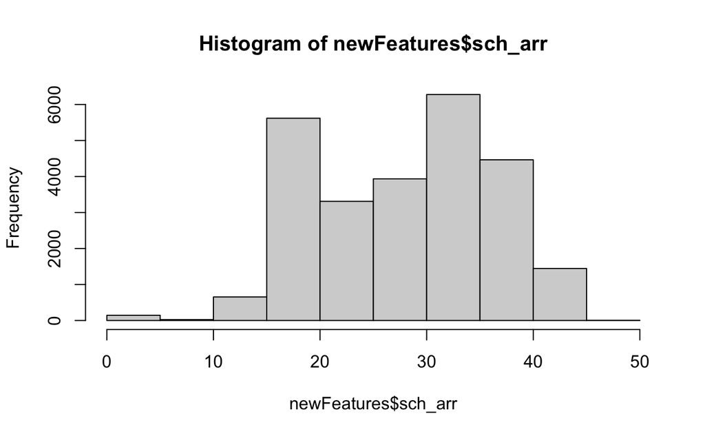

```r
hist(newFeatures$sch_arr)
```

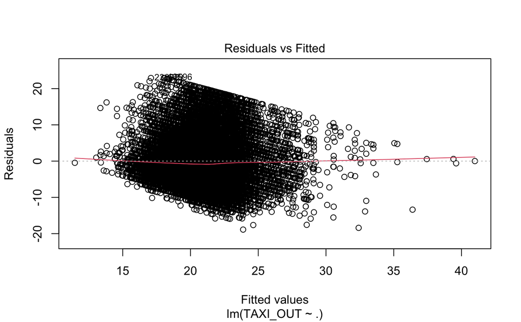

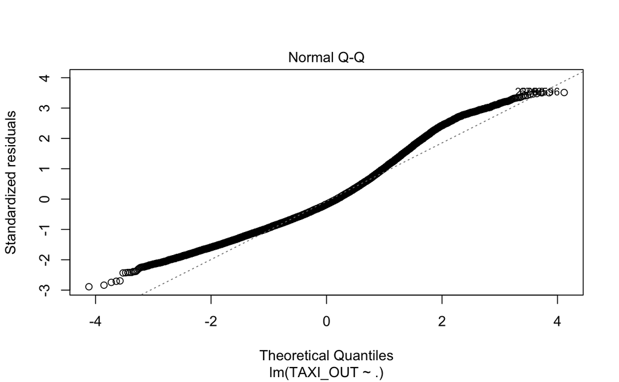

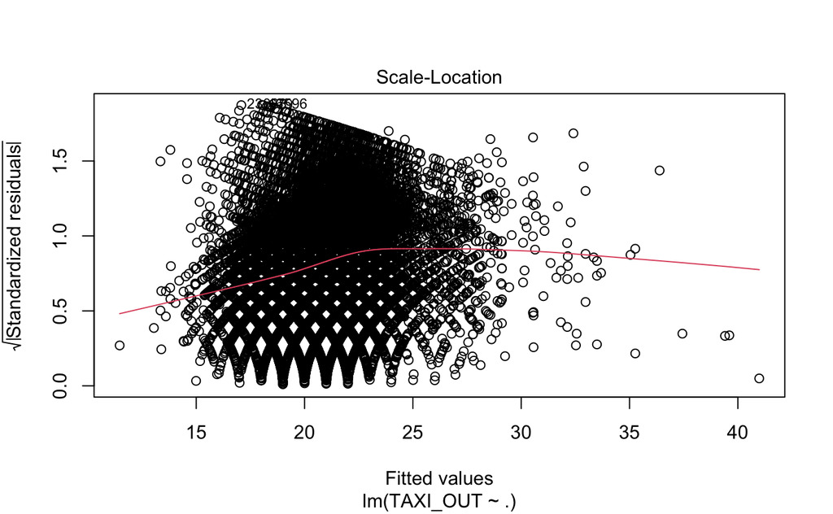

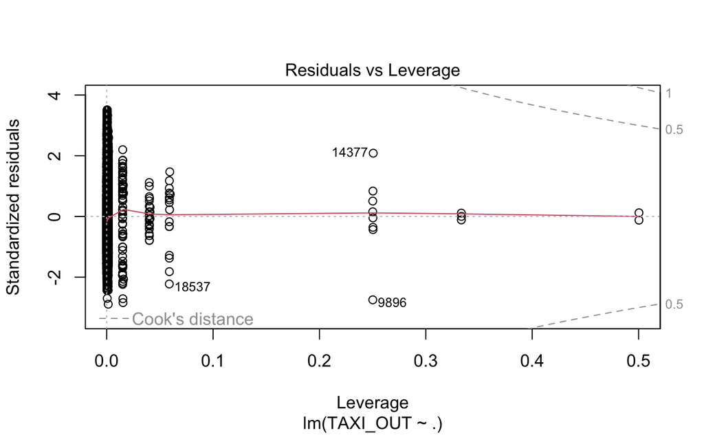

```r
cor(newFeatures$Wind.Gust, newFeatures$Pressure)
```

```
[1] -0.1862336
```